[interactive chart not shown]

# Sivan

stay hungry,stay foolish

[interactive chart not shown]

# Hexo教程

2017-07-06

# Hexo

## Hexo是什么

```
hexo就是Node.js生态系统的一个包，而npm生态系统的包管理器。
```

## Hexo怎么安装

[output not shown]

```
npm install hexo-cli -g
hexo init blog
cd blog
npm install
hexo server
```

- Hexo
- Hexo 教程

展开全文 >>

# Markdown

2017-07-06

# Mardown

最重要的一条就是条目后边必须留空格，不然报错没商量

## 代码高亮

[output not shown]

```
Normal <- c(0.83, 0.79, 0.99, 0.69)
Cancer <- c(0.56, 0.56, 0.64, 0.52)
m <- c(mean(Normal), mean(Cancer))
s <- c(sd(Normal), sd(Cancer))
```

## To—do List

- 项目1
- 项目2
- 项目3
- MarKdown
- Mardown 教程

展开全文 >>

# test1

2017-07-05

## test

```
1
```

```
knitr::opts_chunk$set(echo = TRUE)
```

## test

[output not shown]

[output not shown]

- test
- test

展开全文 >>

# Hello World

2017-07-05

Welcome to [Hexo](https://hexo.io/)! This is your very first post. Check [documentation](https://hexo.io/docs/) for more info. If you get any problems when using Hexo, you can find the answer in [troubleshooting](https://hexo.io/docs/troubleshooting.html) or you can ask me on [GitHub](https://github.com/hexojs/hexo/issues).

## Quick Start

### Create a new post

```
1
```

```
$ hexo new "My New Post"
```

More info: [Writing](https://hexo.io/docs/writing.html)

### Run server

```
1
```

```
$ hexo server
```

More info: [Server](https://hexo.io/docs/server.html)

### Generate static files

```
1
```

```
$ hexo generate
```

More info: [Generating](https://hexo.io/docs/generating.html)

### Deploy to remote sites

```
1
```

```
$ hexo deploy
```

More info: [Deployment](https://hexo.io/docs/deployment.html)

- test
- test

展开全文 >>

# test2

2017-07-05

# test.R

Administrator

Tue Jul 04 10:28:48 2017

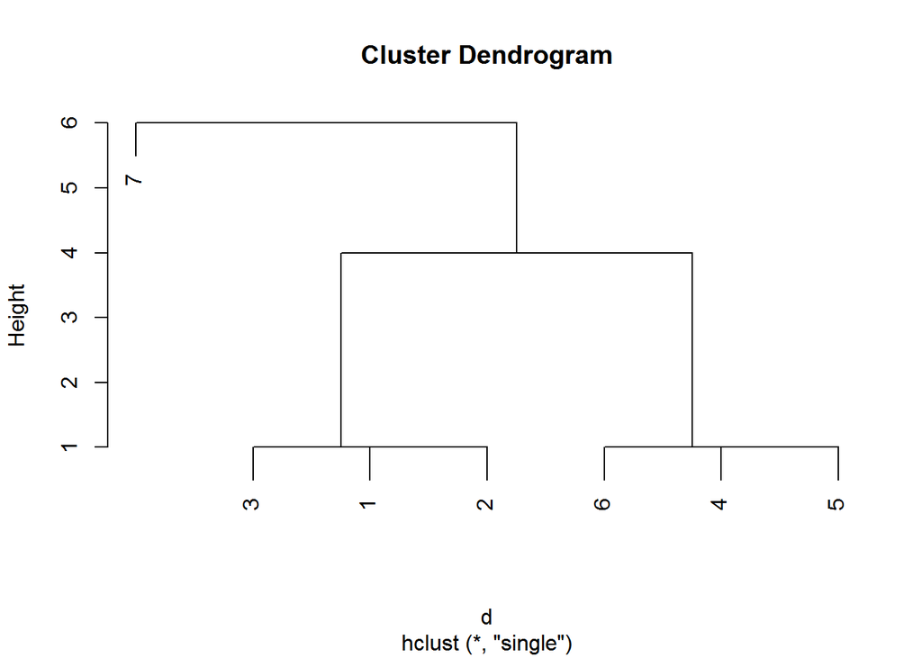

```r
x=c(1,2,3,7,8,9,15)
dim(x)=c(7,1)
d=dist(x)

hc1=hclust(d,"single");
hc2=hclust(d,"complete");
hc3=hclust(d,"median");
hc4=hclust(d,"average");
plot(hc1)
```

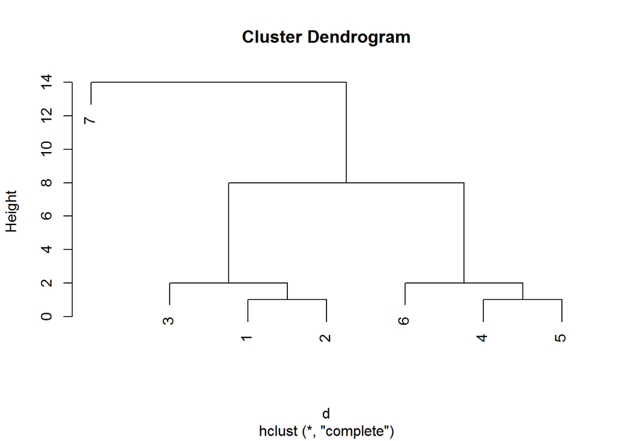

```r
plot(hc2)
```

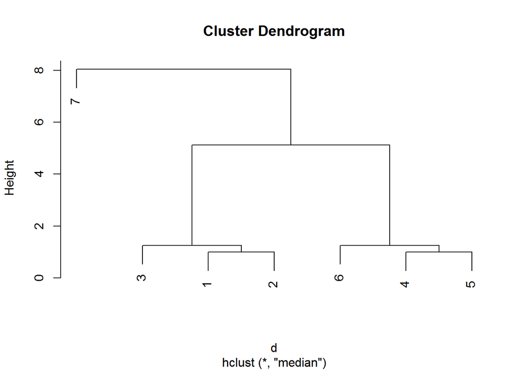

```r
plot(hc3)
```

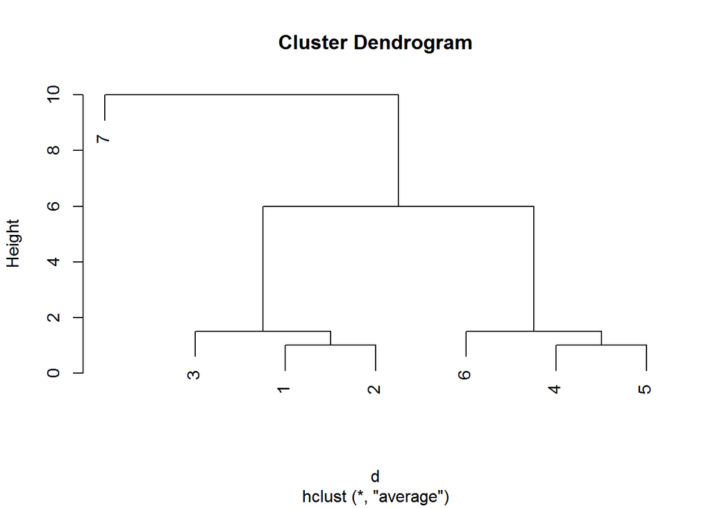

```r
plot(hc4)
```

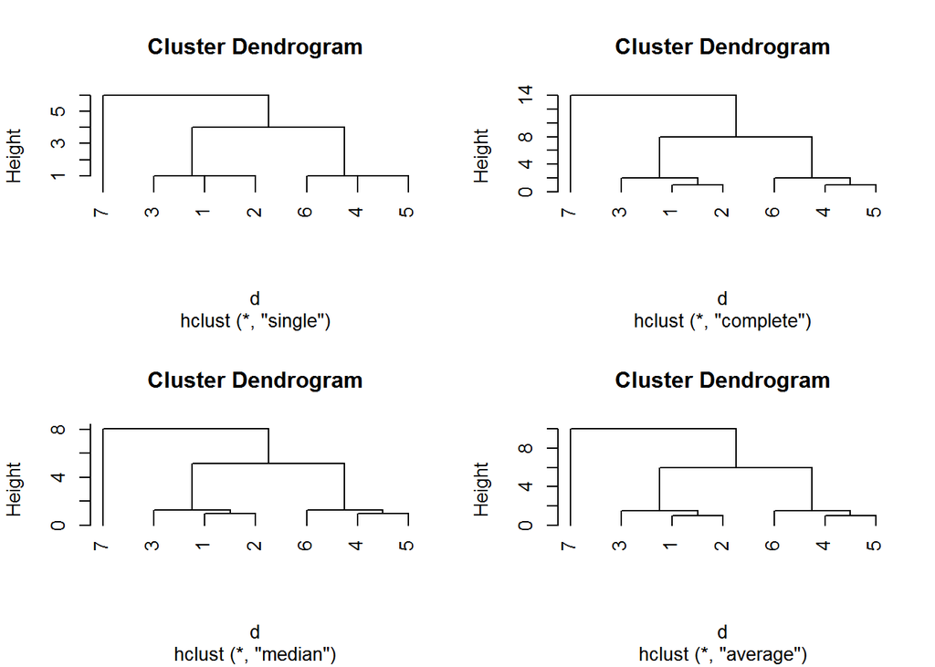

```r
opar=par(mfrow=c(2,2))
plot(hc1,hang=-1);
plot(hc2,hang=-1);
plot(hc3,hang=-1);
plot(hc4,hang=-1);
```

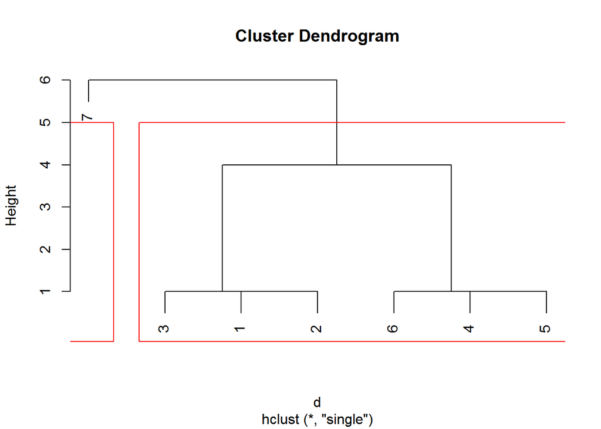

```r
par(opar)

plot(hc1);re=rect.hclust(hc1,k=2)
```

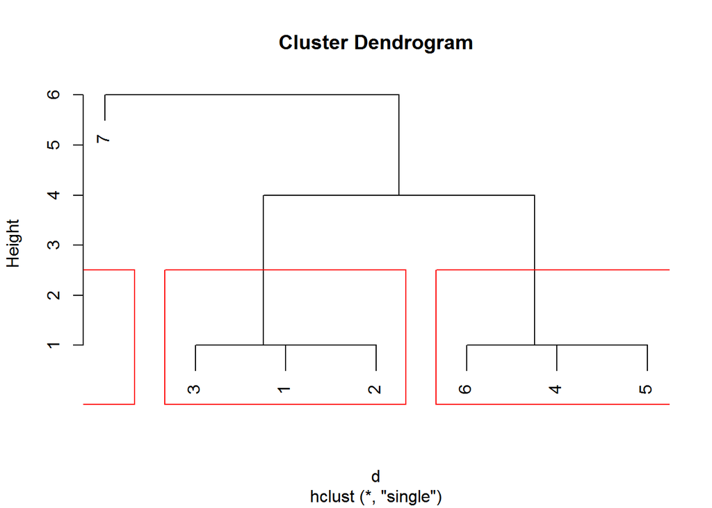

```r
plot(hc1);re=rect.hclust(hc1,k=3)
```

```r
########################

data(iris)
attach(iris)
iris.hc<-hclust(dist(iris[,1:4]))
plot( iris.hc, labels = FALSE, hang = -1)
re <- rect.hclust(iris.hc, k = 3)
iris.id <- cutree(iris.hc, 3)
table(iris.id, Species)
```

```
##        Species
## iris.id setosa versicolor virginica
##       1     50          0         0
##       2      0         23        49
##       3      0         27         1
```

```r
###############K-均值聚类分析
library(fpc)
```

```r
data(iris)
df<-iris[,c(1:4)]
set.seed(252964) # 设置随机值，为了得到一致结果。
(kmeans <- kmeans(na.omit(df), 3)) # 显示K-均值聚类结果
```

```
## K-means clustering with 3 clusters of sizes 38, 62, 50
##
## Cluster means:
##   Sepal.Length Sepal.Width Petal.Length Petal.Width
## 1     6.850000    3.073684     5.742105    2.071053
## 2     5.901613    2.748387     4.393548    1.433871
## 3     5.006000    3.428000     1.462000    0.246000
##
## Clustering vector:
##   1   2   3   4   5   6   7   8   9  10  11  12  13  14  15  16  17  18
##   3   3   3   3   3   3   3   3   3   3   3   3   3   3   3   3   3   3
##  19  20  21  22  23  24  25  26  27  28  29  30  31  32  33  34  35  36
##   3   3   3   3   3   3   3   3   3   3   3   3   3   3   3   3   3   3
##  37  38  39  40  41  42  43  44  45  46  47  48  49  50  51  52  53  54
##   3   3   3   3   3   3   3   3   3   3   3   3   3   3   2   2   1   2
##  55  56  57  58  59  60  61  62  63  64  65  66  67  68  69  70  71  72
##   2   2   2   2   2   2   2   2   2   2   2   2   2   2   2   2   2   2
##  73  74  75  76  77  78  79  80  81  82  83  84  85  86  87  88  89  90
##   2   2   2   2   2   1   2   2   2   2   2   2   2   2   2   2   2   2
##  91  92  93  94  95  96  97  98  99 100 101 102 103 104 105 106 107 108
##   2   2   2   2   2   2   2   2   2   2   1   2   1   1   1   1   2   1
## 109 110 111 112 113 114 115 116 117 118 119 120 121 122 123 124 125 126
##   1   1   1   1   1   2   2   1   1   1   1   2   1   2   1   2   1   1
## 127 128 129 130 131 132 133 134 135 136 137 138 139 140 141 142 143 144
##   2   2   1   1   1   1   1   2   1   1   1   1   2   1   1   1   2   1
## 145 146 147 148 149 150
##   1   1   2   1   1   2
##
## Within cluster sum of squares by cluster:
## [1] 23.87947 39.82097 15.15100
##  (between_SS / total_SS =  88.4 %)
##
## Available components:
##
## [1] "cluster"      "centers"      "totss"        "withinss"
## [5] "tot.withinss" "betweenss"    "size"         "iter"
## [9] "ifault"
```

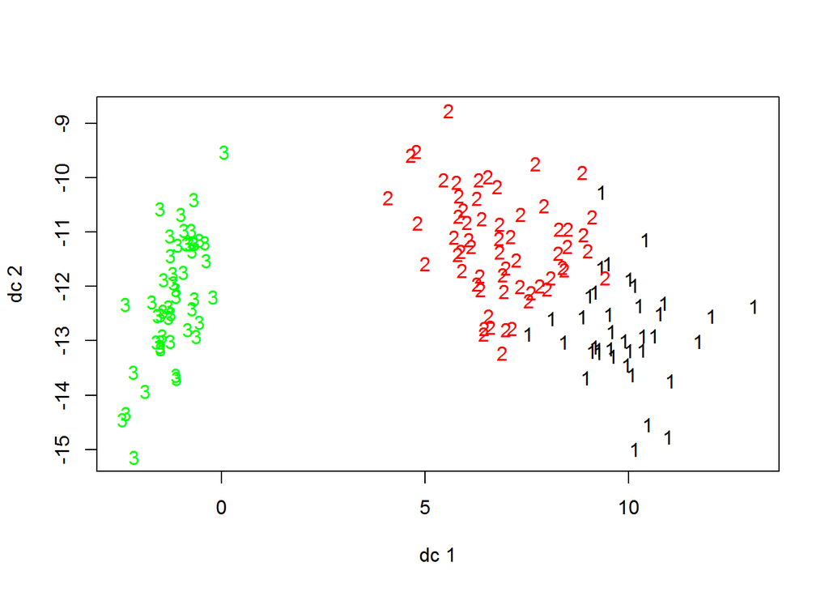

```r
plotcluster(na.omit(df), kmeans$cluster) # 生成聚类图
```

- test
- test

展开全文 >>

tag:

[output not shown]

很惭愧<br><br>只做了一点微小的工作<br>谢谢大家